# Functions

Andriy Koval

2/25/2020

```r
rm( list = ls(all = TRUE)) # to clean the environment
cat("\014") # to clean the console
```

```r
library(magrittr) # pipes
library(dplyr)    # wrangling
library(ggplot2)  # graphing
library(tidyr)    # pivoting
```

# Simulate data

1. Simulate data for performance on three exames with the following specifications:
- There are the total of 100 students in the class
- Exam 1 has the mean of 60 and standard deviation of 7
- Exam 2 has the mean of 73 and standard deviation of 9
- Exam 3 has the mean of 80 and standard deviation of 12
- There is a 7 % chance for a student to miss any of the exams
2. create a histogram featuring all three exames faceted vertically (hist: same x axis)

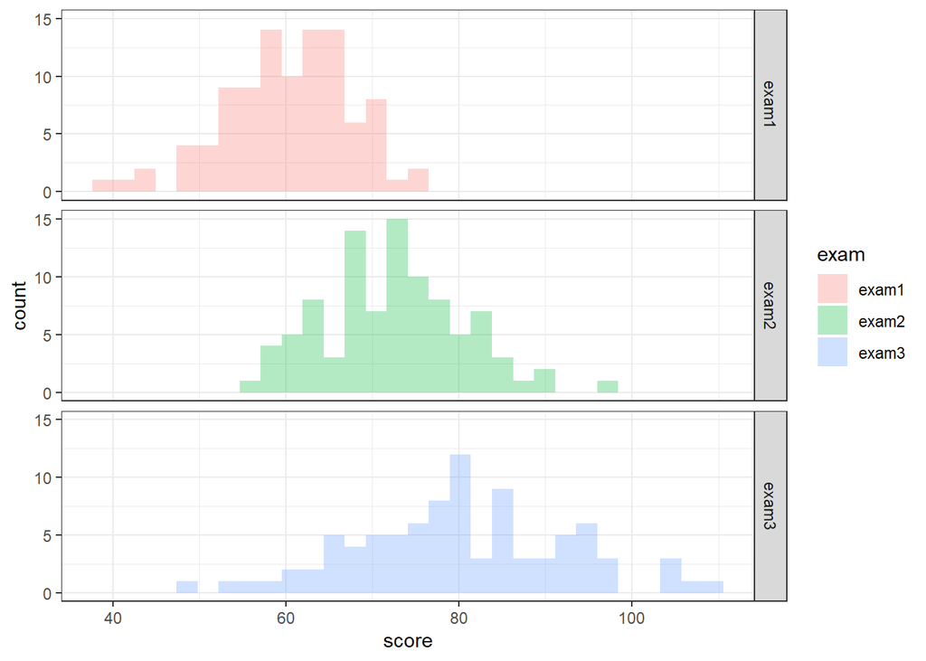

```r
set.seed(42)
class_size <- 100
ds <- tibble::tibble(
  student_id = 1:class_size
  ,"exam1" = rnorm( n = class_size, mean = 60, sd = 7 )
  ,"exam2" = rnorm( n = class_size, mean = 73, sd = 9 )
  ,"exam3" = rnorm( n = class_size, mean = 80, sd = 12 )
  ,"exam1_missed" = runif(n = class_size ) < .07
  ,"exam2_missed" = runif(n = class_size ) < .07
  ,"exam3_missed" = runif(n = class_size ) < .07
) %>%
  dplyr::mutate(
    exam1  = ifelse(exam1_missed, NA, exam1)
    ,exam2 = ifelse(exam2_missed, NA, exam2)
    ,exam3 = ifelse(exam3_missed, NA, exam3)
  ) %>%
  dplyr::select(-exam1_missed, -exam2_missed, -exam3_missed)

ds %>%
  tidyr::pivot_longer(
    cols = c("exam1", "exam2", "exam3")
    ,names_to = "exam"
    ,values_to = "score"
  ) %>%
  ggplot( aes(x = score, fill = exam)) +
  geom_histogram(alpha = .3)+
  facet_grid(exam ~ .)+
  theme_bw()
```

# Compute total score

3. compute the total score for each student.

Hints:  
- you will need to use perform rowwise computation using either `rowwise` or `base::rowSums`  
- don’t forget about `NA` values, each student must have a total score

```r
ds %>% glimpse()
```

```
## Observations: 100
## Variables: 4
## $ student_id <int> 1, 2, 3, 4, 5, 6, 7, 8, 9, 10, 11, 12, 13, 14, 15, 16, 1...
## $ exam1      <dbl> 69.59671, 56.04711, 62.54190, 64.43004, 62.82988, 59.257...
## $ exam2      <dbl> 83.80869, 82.40276, 63.97112, 89.63634, 66.99904, 73.949...
## $ exam3      <dbl> 55.98885, 84.00533, 94.05590, 104.71447, 63.47766, 66.18...
```

```r
# solution 1
ds1 <- ds %>%
  rowwise %>%
  dplyr::mutate(
    total_score = sum(exam1, exam2, exam3, na.rm = TRUE)
  )
ds1
```

```
## Source: local data frame [100 x 5]
## Groups: <by row>
##
## # A tibble: 100 x 5
##    student_id exam1 exam2 exam3 total_score
##         <int> <dbl> <dbl> <dbl>       <dbl>
##  1          1  69.6  83.8  56.0        209.
##  2          2  56.0  82.4  84.0        222.
##  3          3  62.5  64.0  94.1        221.
##  4          4  64.4  89.6 105.         259.
##  5          5  62.8  67.0  63.5        193.
##  6          6  59.3  73.9  66.2        199.
##  7          7  70.6  69.2  71.5        211.
##  8          8  59.3  71.9  67.4        199.
##  9          9  74.1  74.7  72.3        221.
## 10         10  59.6  74.1  77.8        211.
## # ... with 90 more rows
```

```r
# solution 2
ds2 <- ds %>%
  dplyr::mutate(
    total_score = rowSums(ds %>% select(exam1, exam2, exam3), na.rm = TRUE)
  )

ds2
```

```
## # A tibble: 100 x 5
##    student_id exam1 exam2 exam3 total_score
##         <int> <dbl> <dbl> <dbl>       <dbl>
##  1          1  69.6  83.8  56.0        209.
##  2          2  56.0  82.4  84.0        222.
##  3          3  62.5  64.0  94.1        221.
##  4          4  64.4  89.6 105.         259.
##  5          5  62.8  67.0  63.5        193.
##  6          6  59.3  73.9  66.2        199.
##  7          7  70.6  69.2  71.5        211.
##  8          8  59.3  71.9  67.4        199.
##  9          9  74.1  74.7  72.3        221.
## 10         10  59.6  74.1  77.8        211.
## # ... with 90 more rows
```

# Design the graph

We would like to design the graph that would plot the progress of any given student.  
Hints:  
- start by subsetting data for a single student  
- You will need to isolate the values of the total score and compute the number of missing exams, store each as a numeric vector of length 1  
- when you have 1x1 tibble, a good trick to convert it to a vector of legnth 1 is to add `%>% as.list() %>% unlist() %>% as.numeric()` at the end of the expression  
- you will need to `pivot_longer` in order to make your graph  
- you will need to use `geom_point`, `geom_line`, and `geom_text`  
- don’t forget about `aes(group = )` in your `geom_line`

```r
selected_student_id = 1

d <- ds1 %>%
  filter(student_id == selected_student_id ) %>%
  tidyr::pivot_longer(c(exam1, exam2, exam3, total_score), names_to = "assessment", values_to = "score")
d
```

```
## # A tibble: 4 x 3
##   student_id assessment  score
##        <int> <chr>       <dbl>
## 1          1 exam1        69.6
## 2          1 exam2        83.8
## 3          1 exam3        56.0
## 4          1 total_score 209.
```

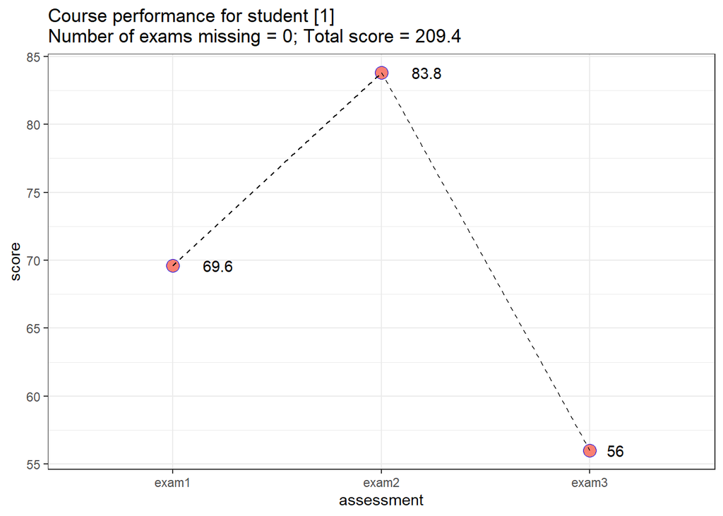

```r
selected_total_score <- d %>% filter(assessment == "total_score") %>% select(score) %>% as.list() %>% unlist() %>% as.numeric()
n_exams_missing <- d %>% filter(!assessment == "total_score") %>% summarize( n_missing = sum(is.na(score))) %>% as.list() %>% unlist() %>% as.numeric()

d %>%
  filter(!assessment == "total_score") %>%
  ggplot(aes(x = assessment, y = score  ))+
  geom_point(shape = 21, fill = "salmon", color = "blue", size = 4)+
  geom_line(aes(group = student_id), linetype = "dashed")+
  geom_text(aes(label = score %>% round(1)), hjust = -1)+
  labs(
    title = paste0(
      "Course performance for student [", selected_student_id,"]","\n",
      "Number of exams missing = ", n_exams_missing, "; Total score = ", selected_total_score %>% round(1)
    )
  )+
  theme_bw()
```

# Compose a function to plot one student

Create a function called `graph_student_progress` to plot all three exam scores. Hints: - Your function should have two arguments: `d` and `selected_student_id`

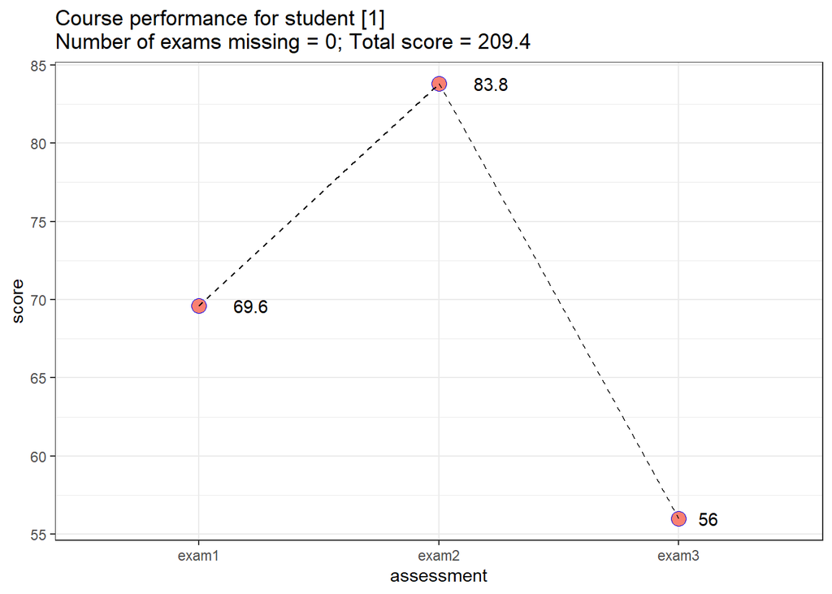

```r
graph_student_progress <- function(d, selected_student_id){
  # subset data to focus on the relevant student
  d1 <- d %>%
    filter(student_id == selected_student_id ) %>%
    tidyr::pivot_longer(c(exam1, exam2, exam3, total_score), names_to = "assessment", values_to = "score")
  # extract a value of the total score to use in the title
  selected_total_score <- d1 %>% filter(assessment == "total_score") %>% select(score) %>%
    as.list() %>% unlist() %>% as.numeric()
  # extact a value of the number of missing exams to use in the title
  n_exams_missing <- d1 %>% filter(!assessment == "total_score") %>% summarize( n_missing = sum(is.na(score))) %>%
    as.list() %>% unlist() %>% as.numeric()
  # plot the graph
  g <- d1 %>%
    filter(!assessment == "total_score") %>%
    ggplot(aes(x = assessment, y = score  ))+
    geom_point(shape = 21, fill = "salmon", color = "blue", size = 4)+
    geom_line(aes(group = student_id), linetype = "dashed")+
    geom_text(aes(label = score %>% round(1)), hjust = -1)+
    labs(
      title = paste0(
        "Course performance for student [", selected_student_id,"]","\n",
        "Number of exams missing = ", n_exams_missing, "; Total score = ", selected_total_score %>% round(1)
      )
    )+
    theme_bw()
  return(g)
}
# How to use
ds1 %>% graph_student_progress(1)
```

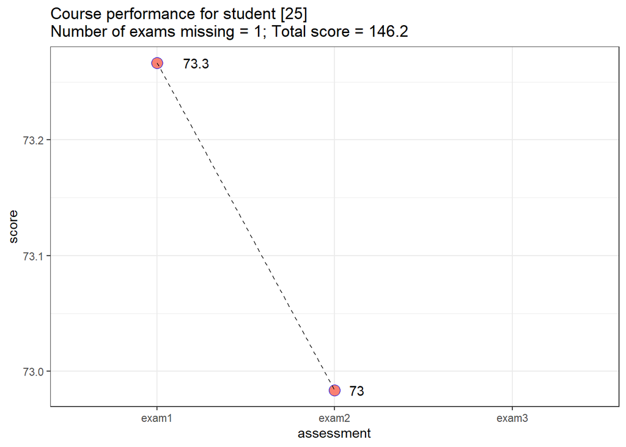

```r
ds1 %>% graph_student_progress(25)
```

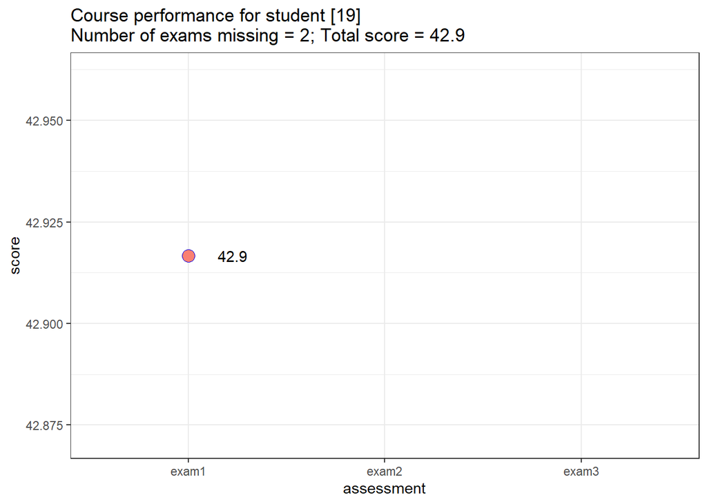

```r
ds1 %>% graph_student_progress(19)
```